# Individual Task 1 – Fonterra Social Media Analysis

## 7.3 7.3 ANOVA

```r
# ANOVA 1: does log engagement differ by platform?

# Group means and SDs (log scale)
fonterra |>
  group_by(platform) |>
  summarise(n = n(), mean_log_eng = mean(log_engagement), sd_log_eng = sd(log_engagement),
            .groups = "drop") |>
  arrange(desc(mean_log_eng)) |>
  kable(digits = 2, caption = "Log engagement by platform")
```

Log engagement by platform

| platform | n | mean_log_eng | sd_log_eng |
| --- | --- | --- | --- |
| LinkedIn | 326 | 5.01 | 0.79 |
| Instagram | 519 | 4.81 | 0.70 |
| Facebook | 1433 | 4.33 | 1.48 |
| TikTok | 108 | 2.48 | 1.26 |
| Twitter/X | 6220 | 1.36 | 1.06 |
| YouTube | 395 | 0.91 | 1.26 |

```r
# Welch ANOVA (does not assume equal variances, which is appropriate here)
welch_platform <- oneway.test(log_engagement ~ platform, data = fonterra, var.equal = FALSE)

tibble(F = unname(welch_platform$statistic),
       df_num = unname(welch_platform$parameter[1]),
       df_denom = unname(welch_platform$parameter[2]),
       p_value = format.pval(welch_platform$p.value, digits = 3, eps = 1e-16)) |>
  kable(digits = 2, caption = "Welch ANOVA: log engagement by platform")
```

Welch ANOVA: log engagement by platform

| F | df_num | df_denom | p_value |
| --- | --- | --- | --- |
| 3689.42 | 5 | 714.58 | <1e-16 |

```r
# Classic ANOVA table and effect size (eta-squared)
aov_platform <- aov(log_engagement ~ platform, data = fonterra)
summary(aov_platform)
```

```
##               Df Sum Sq Mean Sq F value Pr(>F)
## platform       5  17574    3515    2774 <2e-16 ***
## Residuals   8995  11397       1
## ---
## Signif. codes:  0 '***' 0.001 '**' 0.01 '*' 0.05 '.' 0.1 ' ' 1
```

```r
effectsize::eta_squared(aov_platform)
```

```
## For one-way between subjects designs, partial eta squared is equivalent
##   to eta squared. Returning eta squared.
```

| Parameter | Eta2 | CI | CI_low | CI_high |
| --- | --- | --- | --- | --- |
| platform | 0.607 | 0.95 | 0.598 | 1 |

```r
# Games-Howell post hoc test for all platform pairs (estimate = group2 minus group1, log scale)
gh_platform <- fonterra |> games_howell_test(log_engagement ~ platform)

gh_platform |>
  dplyr::select(group1, group2, estimate, conf.low, conf.high, p.adj, p.adj.signif) |>
  kable(digits = 3, caption = "Games-Howell post hoc test: platform pairs")
```

Games-Howell post hoc test: platform pairs

| group1 | group2 | estimate | conf.low | conf.high | p.adj | p.adj.signif |
| --- | --- | --- | --- | --- | --- | --- |
| Facebook | Instagram | 0.479 | 0.337 | 0.621 | 0.000 | **** |
| Facebook | LinkedIn | 0.682 | 0.515 | 0.850 | 0.000 | **** |
| Facebook | TikTok | -1.852 | -2.220 | -1.483 | 0.000 | **** |
| Facebook | Twitter/X | -2.963 | -3.081 | -2.845 | 0.000 | **** |
| Facebook | YouTube | -3.412 | -3.626 | -3.199 | 0.000 | **** |
| Instagram | LinkedIn | 0.204 | 0.051 | 0.356 | 0.002 | ** |
| Instagram | TikTok | -2.330 | -2.692 | -1.968 | 0.000 | **** |
| Instagram | Twitter/X | -3.442 | -3.538 | -3.346 | 0.000 | **** |
| Instagram | YouTube | -3.891 | -4.093 | -3.690 | 0.000 | **** |
| LinkedIn | TikTok | -2.534 | -2.906 | -2.162 | 0.000 | **** |
| LinkedIn | Twitter/X | -3.645 | -3.776 | -3.515 | 0.000 | **** |
| LinkedIn | YouTube | -4.095 | -4.315 | -3.875 | 0.000 | **** |
| TikTok | Twitter/X | -1.112 | -1.465 | -0.758 | 0.000 | **** |
| TikTok | YouTube | -1.561 | -1.955 | -1.167 | 0.000 | **** |
| Twitter/X | YouTube | -0.449 | -0.635 | -0.264 | 0.000 | **** |

```r
# ANOVA 2: does log engagement differ by day of week?

# Group means and SDs (log scale)
fonterra |>
  group_by(day_of_week) |>
  summarise(n = n(), mean_log_eng = mean(log_engagement), sd_log_eng = sd(log_engagement),
            .groups = "drop") |>
  kable(digits = 2, caption = "Log engagement by day of week")
```

Log engagement by day of week

| day_of_week | n | mean_log_eng | sd_log_eng |
| --- | --- | --- | --- |
| Mon | 1352 | 2.31 | 1.85 |
| Tue | 1572 | 2.03 | 1.72 |
| Wed | 1867 | 2.06 | 1.72 |
| Thu | 1811 | 2.24 | 1.83 |
| Fri | 1123 | 2.25 | 1.77 |
| Sat | 388 | 1.93 | 1.75 |
| Sun | 888 | 2.17 | 1.92 |

```r
# Classic ANOVA table and effect size
aov_day <- aov(log_engagement ~ day_of_week, data = fonterra)
summary(aov_day)
```

```
##               Df Sum Sq Mean Sq F value   Pr(>F)
## day_of_week    6    117  19.539    6.09 2.23e-06 ***
## Residuals   8994  28854   3.208
## ---
## Signif. codes:  0 '***' 0.001 '**' 0.01 '*' 0.05 '.' 0.1 ' ' 1
```

```r
effectsize::eta_squared(aov_day)   # the CI upper bound of 1.00 is normal (one-sided interval)
```

```
## For one-way between subjects designs, partial eta squared is equivalent
##   to eta squared. Returning eta squared.
```

| Parameter | Eta2 | CI | CI_low | CI_high |
| --- | --- | --- | --- | --- |
| day_of_week | 0.00405 | 0.95 | 0.00167 | 1 |

```r
# Welch check: same conclusion without the equal-variance assumption
oneway.test(log_engagement ~ day_of_week, data = fonterra, var.equal = FALSE)
```

```
##
##  One-way analysis of means (not assuming equal variances)
##
## data:  log_engagement and day_of_week
## F = 6.1853, num df = 6.0, denom df = 2841.6, p-value = 1.844e-06
```

```r
# Order platforms by mean log engagement so the plot matches the ANOVA table
platform_order <- fonterra |>
  group_by(platform) |>
  summarise(mean_log_eng = mean(log_engagement), .groups = "drop") |>
  arrange(desc(mean_log_eng)) |>
  pull(platform)

# Results pulled from the ANOVA chunks, so the plot subtitle always matches the output
eta_platform <- effectsize::eta_squared(aov_platform)[[2]][1]
```

```
## For one-way between subjects designs, partial eta squared is equivalent
##   to eta squared. Returning eta squared.
```

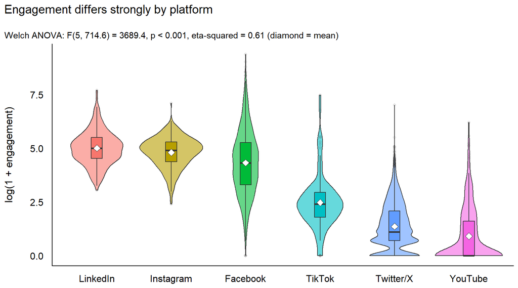

```r
# Plot 1: log engagement by platform (violin = distribution, box = quartiles, diamond = mean)
fonterra |>
  mutate(platform = factor(platform, levels = platform_order)) |>
  ggplot(aes(platform, log_engagement, fill = platform)) +
  geom_violin(show.legend = FALSE, alpha = 0.6) +
  geom_boxplot(width = 0.15, show.legend = FALSE, outlier.alpha = 0.1) +
  stat_summary(fun = mean, geom = "point", shape = 23, size = 3,
               fill = "white", show.legend = FALSE) +
  labs(title = "Engagement differs strongly by platform",
       subtitle = sprintf("Welch ANOVA: F(%.0f, %.1f) = %.1f, p < 0.001, eta-squared = %.2f (diamond = mean)",
                          welch_platform$parameter[1], welch_platform$parameter[2],
                          welch_platform$statistic, eta_platform),
       x = NULL, y = "log(1 + engagement)") +
  theme_modern()
```

```r
# Results for the weekday ANOVA
aov_day_tab <- summary(aov_day)[[1]]
eta_day <- effectsize::eta_squared(aov_day)[[2]][1]
```

```
## For one-way between subjects designs, partial eta squared is equivalent
##   to eta squared. Returning eta squared.
```

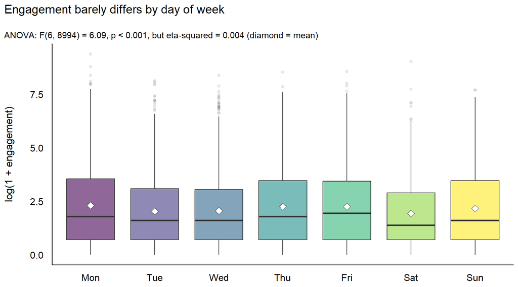

```r
# Plot 2: log engagement by day of week (shows that differences are small)
fonterra |>
  ggplot(aes(day_of_week, log_engagement, fill = day_of_week)) +
  geom_boxplot(show.legend = FALSE, outlier.alpha = 0.1, alpha = 0.6) +
  stat_summary(fun = mean, geom = "point", shape = 23, size = 3,
               fill = "white", show.legend = FALSE) +
  labs(title = "Engagement barely differs by day of week",
       subtitle = sprintf("ANOVA: F(%d, %d) = %.2f, p < 0.001, but eta-squared = %.3f (diamond = mean)",
                          aov_day_tab[["Df"]][1], aov_day_tab[["Df"]][2],
                          aov_day_tab[["F value"]][1], eta_day),
       x = NULL, y = "log(1 + engagement)") +
  theme_modern()
```

## 7.4 7.4 Chi-squared tests (Categorical vs categorical)

```r
run_chisq <- function(data, a, b) {
  tab <- table(data[[a]], data[[b]])
  test <- chisq.test(tab)
  list(table = tab,
       test = test,
       min_expected = min(test$expected),
       cramers_v = effectsize::cramers_v(tab),
       std_resid = round(test$stdres, 1))
}

# (a) Platform vs having media
res1 <- run_chisq(fonterra, "platform", "media_present"); res1
```

```
## $table
##
##             No media Has media
##   Facebook       680       753
##   Instagram        0       519
##   LinkedIn        94       232
##   TikTok           0       108
##   Twitter/X     6220         0
##   YouTube          0       395
##
## $test
##
##  Pearson's Chi-squared test
##
## data:  tab
## X-squared = 6552.5, df = 5, p-value < 2.2e-16
##
##
## $min_expected
## [1] 24.08132
##
## $cramers_v
## Cramer's V (adj.) |       95% CI
## --------------------------------
## 0.85              | [0.84, 1.00]
##
## - One-sided CIs: upper bound fixed at [1.00].
## $std_resid
##
##             No media Has media
##   Facebook     -30.0      30.0
##   Instagram    -43.8      43.8
##   LinkedIn     -21.6      21.6
##   TikTok       -19.5      19.5
##   Twitter/X     76.0     -76.0
##   YouTube      -37.9      37.9
```

```r
# (b) Platform vs engagement level (High = above median of 5)
res2 <- run_chisq(fonterra, "platform", "engagement_level"); res2
```

```
## $table
##
##              Low High
##   Facebook    61 1372
##   Instagram    0  519
##   LinkedIn     0  326
##   TikTok      32   76
##   Twitter/X 4328 1892
##   YouTube    307   88
##
## $test
##
##  Pearson's Chi-squared test
##
## data:  tab
## X-squared = 3122.7, df = 5, p-value < 2.2e-16
##
##
## $min_expected
## [1] 51.2703
##
## $cramers_v
## Cramer's V (adj.) |       95% CI
## --------------------------------
## 0.59              | [0.57, 1.00]
##
## - One-sided CIs: upper bound fixed at [1.00].
## $std_resid
##
##               Low  High
##   Facebook  -39.9  39.9
##   Instagram -24.7  24.7
##   LinkedIn  -19.3  19.3
##   TikTok     -4.8   4.8
##   Twitter/X  48.5 -48.5
##   YouTube    10.3 -10.3
```

```r
# (c) Media type vs engagement level
res3 <- run_chisq(fonterra, "media_type", "engagement_level"); res3
```

```
## $table
##
##                      Low High
##   No media recorded 4372 2622
##   Image               13  917
##   Sidecar              0   95
##   Video              343  639
##
## $test
##
##  Pearson's Chi-squared test
##
## data:  tab
## X-squared = 1481.6, df = 3, p-value < 2.2e-16
##
##
## $min_expected
## [1] 45.09888
##
## $cramers_v
## Cramer's V (adj.) |       95% CI
## --------------------------------
## 0.41              | [0.39, 1.00]
##
## - One-sided CIs: upper bound fixed at [1.00].
## $std_resid
##
##                       Low  High
##   No media recorded  35.4 -35.4
##   Image             -33.0  33.0
##   Sidecar           -10.3  10.3
##   Video             -11.7  11.7
```

```r
# (d) Weekend vs engagement level
res4 <- run_chisq(fonterra, "day_type", "engagement_level"); res4
```

```
## $table
##
##            Low High
##   Weekday 4036 3689
##   Weekend  692  584
##
## $test
##
##  Pearson's Chi-squared test with Yates' continuity correction
##
## data:  tab
## X-squared = 1.6535, df = 1, p-value = 0.1985
##
##
## $min_expected
## [1] 605.7491
##
## $cramers_v
## Cramer's V (adj.) |       95% CI
## --------------------------------
## 9.02e-03          | [0.00, 1.00]
##
## - One-sided CIs: upper bound fixed at [1.00].
## $std_resid
##
##            Low High
##   Weekday -1.3  1.3
##   Weekend  1.3 -1.3
```

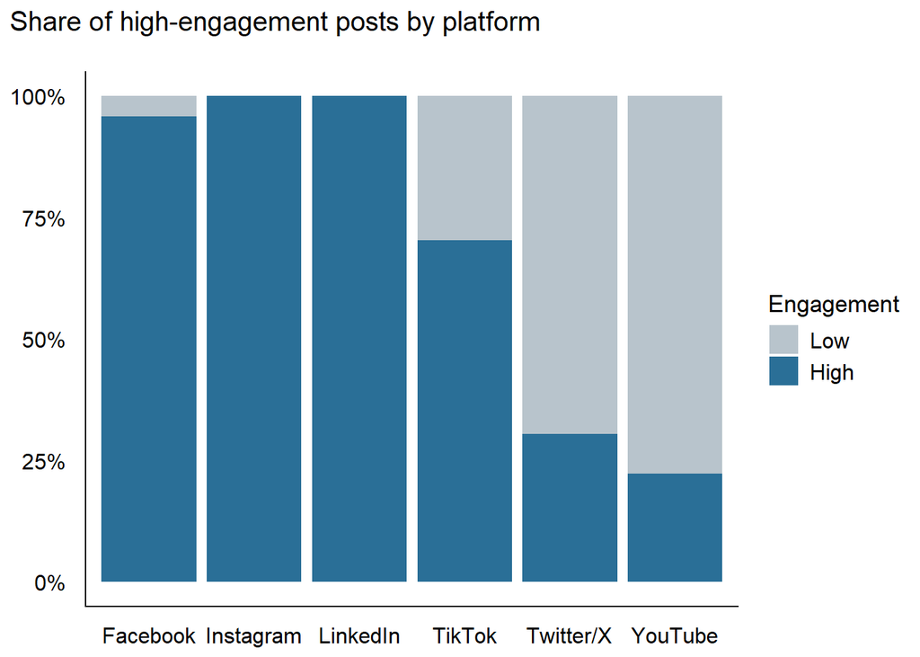

```r
fonterra |>
  count(platform, engagement_level) |>
  group_by(platform) |>
  mutate(pct = n / sum(n)) |>
  ggplot(aes(platform, pct, fill = engagement_level)) +
  geom_col() +
  scale_y_continuous(labels = percent) +
  scale_fill_manual(values = c("#b8c4cc", "#2a6f97")) +
  labs(title = "Share of high-engagement posts by platform",
       x = NULL, y = NULL, fill = "Engagement") +
  theme_modern()
```

## 7.5 7.5 Results and Discussion

**Correlation:** Engagement is moderately and positively related to text length (Spearman rho about 0.45), word count (about 0.43) and year (about 0.49). Among the 886 posts with video play counts, plays and engagement are strongly related (rho about 0.74), and plays and likes similarly (about 0.73). Text length remains related to engagement inside X alone (rho about 0.42), so it is not purely a platform artifact. These are associations, not causal effects.

**ANOVA results (platform and day of week):** The ANOVA tests compare average engagement across groups. Because engagement is very uneven, the tests were run on log-transformed values.

Platform makes a big difference. Engagement differs strongly between platforms (F(5, 714.6) = 3689.4, p < 0.001). Platform alone explains about 61% of the differences in engagement, which is a very large effect. Every pair of platforms differs significantly. LinkedIn and Instagram perform best, then Facebook, then TikTok, X and YouTube.

Day of week hardly matters. The differences between days are statistically significant (F(6, 8994) = 6.09, p < 0.001) only because the dataset is large. They explain just 0.4% of the differences in engagement, so the day a post goes out has no practical effect.

Therefore, Platform is the main factor linked to engagement, so posting decisions should focus on where content is published, not on which day.

**Chi-squared.** Media use is strongly associated with platform (chi-squared about 6,553, df = 5, p < 0.001), which confirms the confounding between platform and media. Being a high-engagement post (above the median of 5) is also strongly associated with platform (chi-squared about 3,123, df = 5, p < 0.001).

**Limitations.** Posts are not independent (same account, campaigns, reposts), the data is observational, the platform and year confounders are not controlled in bivariate tests, and missing counts are platform-specific.

# 8 8. Insights and recommendations

**Key insights**

1. **Most posts get little engagement, and a few get a lot.** The typical post receives about 5 interactions, and about 16% receive none. A small number of very popular posts, mostly on Facebook, pull the average up to about 60. This is why medians describe a typical post better than averages.
2. **Platform is the most important factor.** LinkedIn and Instagram have the highest typical engagement, followed by Facebook. TikTok is lower, and X and YouTube are lowest. Platform alone explains about 61% of the differences in engagement, and every pair of platforms is significantly different. Facebook produces a few viral posts, which give it about 64% of all engagement. X has 69% of the posts but only about 8% of the engagement.
3. **Replies on X lower its results.** About 40% of X posts are replies to customers, and these get much less engagement (median 1) than original posts (median 5). X should therefore not be judged by likes alone.
4. **Media helps, but it depends on the platform.** On Facebook, posts with images or video do better than text-only posts, and video does best. On LinkedIn, media may help, but the evidence is weak. On Instagram, video did worse than images and carousels. X, YouTube and TikTok could not be compared, because X does not record media and YouTube and TikTok are all video. So video is not the best choice everywhere.
5. **Timing matters very little.** Day of the week and month have almost no effect on engagement, and weekends are about the same as weekdays. Time of day was not tested in this report.
6. **Longer posts tend to get more engagement.** This holds even within X alone, so it is not only because some platforms use longer text. It shows a link, not a cause.

**Recommendations**

1. **Focus on LinkedIn, Instagram and Facebook** for brand and campaign content, where engagement is highest.
2. **Use X mainly for customer service and news,** and measure it by response quality and not by likes.
3. **Choose the format for each platform.** Use more video on Facebook, and test images and carousels on Instagram. Do not assume that video works everywhere.
4. **Study the most popular posts,** for example the top 1% on Facebook, to see which topics and formats worked and repeat them.
5. **Do not spend effort choosing the posting day.** Instead, test time of day in the next analysis, since the data has posting times.
6. **Improve the data.** Record shares for Instagram and YouTube, complete the comment counts, record media on X, and add follower numbers so platforms can be compared fairly.

**Limitations:** These results show associations in existing data and do not prove that a change would cause more engagement. Shares are not reported for Instagram and YouTube, so their engagement is understated.

**Next steps:** A regression that considers platform, media, text length and reply status together, and a check of which topics and tones get the most engagement.

# 9 9. GenAI Declaration

I used ChatGpt, Claude and Copilot AI as a supporting tool during this assignment. The tool was used for brainstorming, understanding R syntax, troubleshooting code, suggesting ways to structure the analysis, and improving explanations and writing.

I used GenAI as a supporting tool. I checked the suggested R code against the assignment requirements and ran the code in R using the supplied Fonterra dataset. I also inspected the data, outputs, statistical results, tables and visualisations myself and made the final decisions about data preparation, analysis and interpretation. Where GenAI suggestions were used, I verified that they were appropriate for the variables and statistical techniques covered in the course.